# Notebook3

Tobias Nunn

2025-02-02

# Analysis 1: full genera-to-genera comparison (2025-01-31 to 2025-02-__)

## Introduction

Now that the pipeline is where i want it, all that is left to do is download somewhere north of 500 more accessions, put them on hawk, eggnog them and bring them down to be heatmapped.

## Methods

I started by creating a non-prototype version of “NCBIfastacollectorprototype”, called NCBIfastacollector.R. This is largely only different in so far as it includes filters based around not repeating the fasta files i have already done. This is when i ran into my first roadblock concerning how i create the control files that feed my “slurmsquared.sh” file on hawk. Mainly, how to exclude the fastas that have already been processed in a way that doesn’t rely on a file further down the pipeline. A possible solution i am going to try later is downloading all of the fastas now, create all of the control files now and then apart from the files done in the prototype i don’t have to do any exclusions. I separated “NCBIfastacollector” into it’s major components, this created the script “fasta_control_files.R”. I then modified this file so it would take outputs from the former (and a few other earlier scripts) and cluster the accessions into output directories i can then pass up to hawk, the aim is to create the control script at the same time, but it is late and i could not get there today. I decided to very quickly download the other 861 fastas and JSON files needed for the intra-family analysis for Sphingomanadaceae and Microbacteriaceae. This used the same methods i discussed previously for the genera-genera comparison, but with a different filter on the source list, the notation might be a bit spotty for this as i just wanted to get it done, because i don’t know if the page may go down due to “recent events”. For now, i have stored all of these in my personal onedrive, again, for speed. I then got to work uploading the .fasta files to hawk, with the partnered control file. Batch 1 is up. All of the control files are up. I will add more as space becomes available.

I ran into quite the peculiar thing, i set the memory on hawk to 45gig because when I used “seff” to look at slurm jobs it told me that the jobs used 43 gig, however, i have done it a lot again today, and now it tells me that the jobs take under 9 gigs. I had a look at the previous ones and they still say 43 gigs so maybe there was some error in the code or a variable i had taken out or maybe just random chance i hit a bad one, anyway, i am going to need to update the script for the next batch to only ask for 10 gigs because 8% efficiency is kind of ridiculous, very odd. I set off batch 21 on hawk with some reduced parameters as a bit of a test, 21 is the final batch with only two samples so if something stupid happens then i have only lost one hour of slurm time. It could end up scheduling them faster because they are now seemingly less intensive, but this does raise the question, what happens if one randonmly goes back to 40 gigs? i suppose it just means more will fail and have to be redone, all i can really do here is cross my fingers. Well, that was an abject failure, both crashed due to too little memory, bananas as “seff” said they were still under budget, so now i am thinking it can not be trusted and i am going back to the original parameters, i am just going to have to accept that when its busy there will be no parallel action and they are sometimes going to take an age to schedule, because whenever i try reducing the parameters, something stupid happens.

On Sunday, batches 2,3 and 4 were done in good time. On some occasions i even saw hawk running 4 of my jobs at a time.

## Results

(also: compare with prototype, are the map ids the same, are there differences?)

# Miscelaneous projects whilst in “eggnog limbo” (2025-02-01 to 2025_____)

## Introduction

While i am waiting for eggnog to process all of those files, i figured i should get on with other things that need doing. I created a summary mindmap that can be found in tnunn_research -> 04_images under the same name as the title here. Many of these steps are in service of increasing the transparancy of the opperation, so that when others view it, they can have help to understand all the obscure files, and also so that i can keep track in my head.

## Methods

I am not doing these tasks in any particular order, and some, for example the literature reading will be a long-term process. This started with my investigations into the 43gig vs 9gig problem, however, as that is directly tied to the eggnog process, i will leave that in the above section. I have also begun work on the “HELP.pptx” file that one can use to lookup what files do and where they fit into the pipeline. I have begun a new workbook titled NotebookA_literature_review.Rmd” where I have begun putting notes about the first paper i am reading. I used powershell to zip directories of fastas where these have been sent to hawk already, to save space, these are the commands i used:

[output not shown]

I also did something similar on hawk, using the commands:

```
 find
./ -maxdepth 1 -type d -name “GC” -exec bash -c ‘zip -r “${1%/}.zip”
“$1”’ _ {} ; rm -R ”_annotations”
```

Before my meeting with Aaron tomorrow (2025-02-04) i wanted to do some more sample heatmaps with different parameters, for example, the comparison of difference exluding Sphingomonas and Pantoea, as they seem to dominate the heatmap. I also, wanted to do an analysis of similarity, as common genes could give me an idea of what “requirements” a bacteria may need to have to live in the skin Microbiome.

📌 ?: TODO: I think there is a way to group by pathway using the “class” of the pathway. I want to look into that too.

I had a play around with the different aesthetic themes i could add to the regular prototype heatmap. I used the keggrest package to pull down metadata about each KEGG pathway from the KEGG website. I also added a facet grid to the heatmap to group by “class” a classification system found on the KEGG website.

## Results

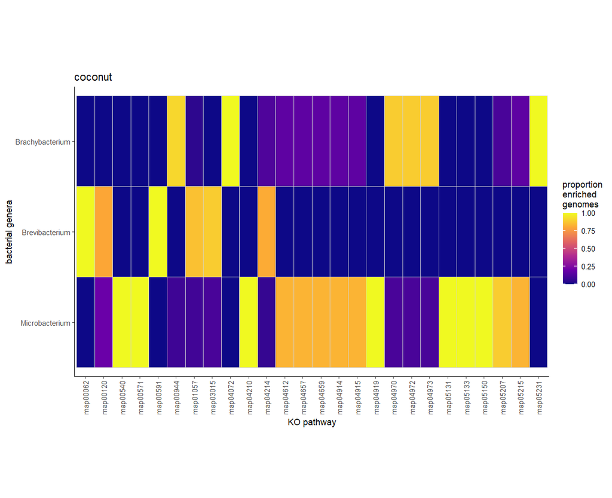

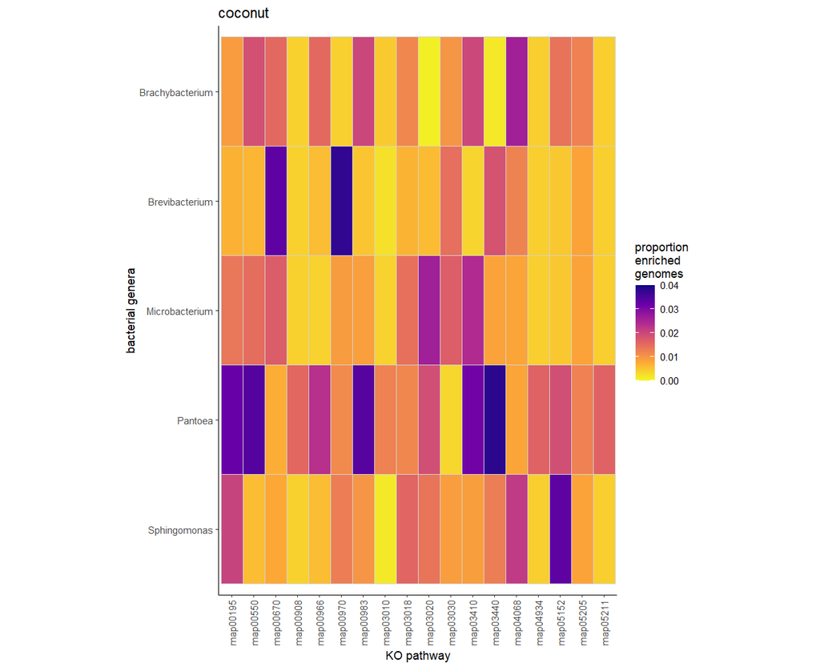

These heatmaps are interesting, but using a heatmap to visualise commonality is slightly odd. I will admit, the time is 21:46 and my notebooking skills may not be the best right now. After my meeting with Aaron, i rejigged the code and now have this:

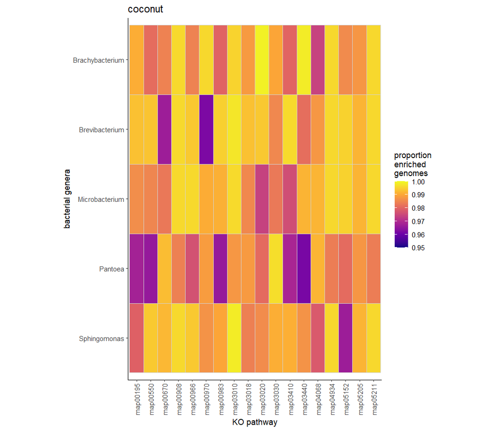

It looks almost identical, but the scale is much more sane this time.

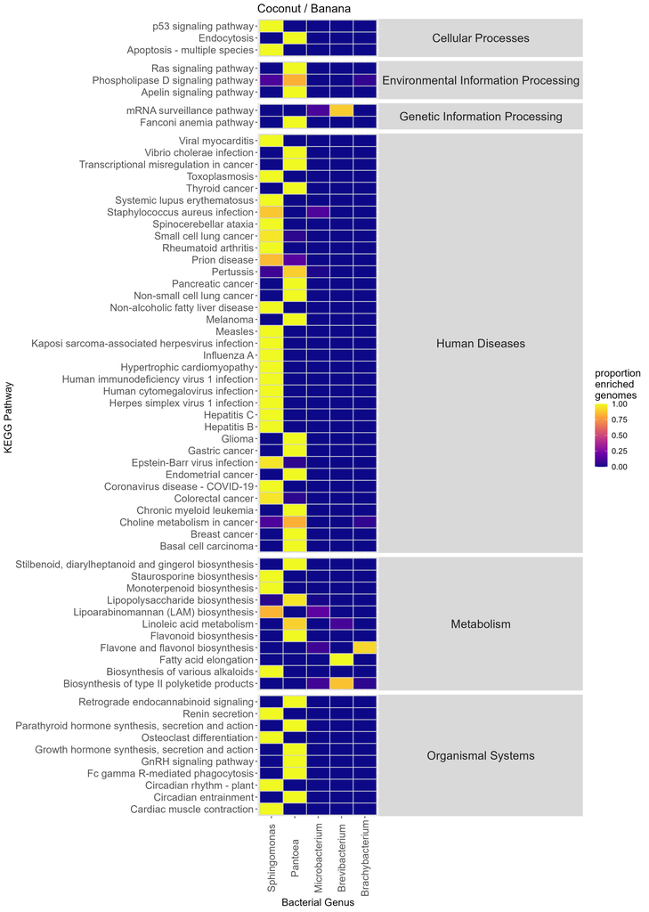

Figure 4 - Latest themes on the prototype heatmap

## Conclusions

The screen i am using is burning my eyes now i’m putting in more consecutive hours, so i am changing the mode to “Gob”, the “tools” tab under global and appearance. I have chosen this dark mode purely for the name Gob, i find it humorous.

# GTDB-TK De-Novo phylogenetic trees (2025-02-05 to 2025-02-__)

## Introduction

A while back, i ran GTDB-TK in order to give me a list of accessions i needed to pull down from the NCBI website. This did output a tree, but i wanted to focus on getting the heatmap processes done. Now i have time whilst those are running to do this with all the bells and whistles.

## Methods

The file this section concerns is called gtdbtk.bac120.decorated.tree. I want to read this file into R, cut it down so i have multiple trees containing the Bangor-made accessions and modify it so that it has nice aesthetics (for example colouring the nodes based on the accession’s status). This serves to identify the species of the Bangor samples at a higher level of accuracy than my work in the summer.

## Conclusion

[figure not shown]